# My Example Computed Manuscript

Created in Rmarkdown

Jeffrey M. Perkel, Technology Editor, Nature

14 Jan 2022 16:35:19 PST

Abstract

A mock computed manuscript created in RStudio using {Rmarkdown}. The {Bookdown} and {Rticles} packages were used to output the text in Springer Nature’s desired manuscript format.

# Introduction

“Literate programming” is a style of programming that uses computational notebooks to weave together code, explanatory text, data and results into a single document, enhancing scientific communication and computational reproducibility.<sup>1–3</sup> (These references were added into the document using RStudio’s integration with the open-source Zotero reference manager<sup>4</sup> plus the [Better BibTeX](https://retorque.re/zotero-better-bibtex/) Zotero plugin.)

Several platforms for creating such documents exist.<sup>5</sup> Typically, these documents interleave code and text ‘blocks’ to build a computational narrative. But some, including R Markdown, Observable, and the JupyterBook extension to the Jupyter ecosystem, also allow authors to include and execute code “inline” – that is, within the text itself.

This makes it possible to create fully executable manuscripts in which the document itself computes and inserts values and figures into the text rather than requiring authors to input them manually. This is in many ways the ‘killer feature’ of computed manuscripts: it circumvents the possibility that the author will enter an incorrect number, or forget to update a figure or value should new data arise.

In this manuscript, created in RStudio using the R Markdown language, we will demonstrate one such example.

# Results

## Inline computation

Imagine we are analyzing data from a clinical trial. We have grouped subjects in three bins and measured the concentration of some metabolite. (These data are simulated.)

Rather than analyzing those data and then copying the results into our manuscript, we can use the programming language `R` to do that in the manuscript itself. Simply enclose the code inside backticks, with the letter `r`. For instance, to calculate the circumference and area of a circle with radius *r* = 10, you could write “A = `` `r pi * r^2` ``” and “C = `` `r 2 * pi * r` ``. Those evaluate to”A = **314.159** and C = **62.832**”.

## Incorporating new data

Combining the two datasets, we have a total of **159** subjects. The revised average metabolite concentration is **185.28** (range: **77 to 299**). We now have **55** subjects in Group 1, **60** subjects in Group 2, and **44** in Group 3.

## Plotting the data

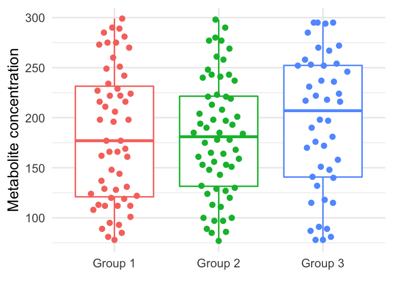

Metabolite concentration of clinical trial subjects

# Code

The following code was used to load, merge, and plot the (simulated) clinical trial data:

```r
# load libraries
library(tidyverse)
library(ggbeeswarm)
library(bookdown)
```

```r
# read in some initial data
df1 <- read_csv('data/example-data-1.csv')
```

```r
# read new dataset
df2 <- read_csv('data/example-data-2.csv')
```

```r
# merge datasets
final_data <- rbind(df1, df2)
```

```r
# plot the data
p <- final_data %>%
  ggplot(aes(x = class, y = conc, color = class)) +
  geom_boxplot() +
  ggbeeswarm::geom_quasirandom(width = 0.25) +
  xlab("") +
  ylab("Metabolite concentration") +
  theme_minimal() +
  theme(legend.position = "none")
p
```

Initial subject data

| ID | Class | Conc | \| | ID | Class | Conc | \| | ID | Class | Conc |
| --- | --- | --- | --- | --- | --- | --- | --- | --- | --- | --- |
| ID_1 | Group 2 | 153 | \| | ID_34 | Group 2 | 221 | \| | ID_67 | Group 3 | 148 |
| ID_2 | Group 1 | 224 | \| | ID_35 | Group 1 | 112 | \| | ID_68 | Group 1 | 281 |
| ID_3 | Group 2 | 127 | \| | ID_36 | Group 3 | 246 | \| | ID_69 | Group 3 | 295 |
| ID_4 | Group 2 | 194 | \| | ID_37 | Group 2 | 190 | \| | ID_70 | Group 2 | 111 |
| ID_5 | Group 1 | 251 | \| | ID_38 | Group 1 | 177 | \| | ID_71 | Group 2 | 132 |
| ID_6 | Group 1 | 81 | \| | ID_39 | Group 1 | 148 | \| | ID_72 | Group 2 | 261 |
| ID_7 | Group 2 | 100 | \| | ID_40 | Group 2 | 290 | \| | ID_73 | Group 1 | 122 |
| ID_8 | Group 1 | 270 | \| | ID_41 | Group 2 | 151 | \| | ID_74 | Group 2 | 124 |
| ID_9 | Group 2 | 100 | \| | ID_42 | Group 2 | 159 | \| | ID_75 | Group 1 | 234 |
| ID_10 | Group 1 | 161 | \| | ID_43 | Group 2 | 113 | \| | ID_76 | Group 2 | 184 |
| ID_11 | Group 3 | 158 | \| | ID_44 | Group 1 | 249 | \| | ID_77 | Group 3 | 272 |
| ID_12 | Group 3 | 118 | \| | ID_45 | Group 1 | 124 | \| | ID_78 | Group 1 | 242 |
| ID_13 | Group 2 | 143 | \| | ID_46 | Group 3 | 87 | \| | ID_79 | Group 2 | 277 |
| ID_14 | Group 2 | 258 | \| | ID_47 | Group 1 | 166 | \| | ID_80 | Group 3 | 236 |
| ID_15 | Group 3 | 224 | \| | ID_48 | Group 1 | 196 | \| | ID_81 | Group 1 | 101 |
| ID_16 | Group 3 | 254 | \| | ID_49 | Group 1 | 112 | \| | ID_82 | Group 3 | 218 |
| ID_17 | Group 3 | 190 | \| | ID_50 | Group 1 | 289 | \| | ID_83 | Group 2 | 130 |
| ID_18 | Group 2 | 148 | \| | ID_51 | Group 2 | 161 | \| | ID_84 | Group 1 | 128 |
| ID_19 | Group 1 | 89 | \| | ID_52 | Group 3 | 270 | \| | ID_85 | Group 3 | 252 |
| ID_20 | Group 2 | 89 | \| | ID_53 | Group 2 | 237 | \| | ID_86 | Group 1 | 198 |
| ID_21 | Group 3 | 253 | \| | ID_54 | Group 2 | 280 | \| | ID_87 | Group 1 | 169 |
| ID_22 | Group 3 | 231 | \| | ID_55 | Group 2 | 175 | \| | ID_88 | Group 2 | 185 |
| ID_23 | Group 1 | 112 | \| | ID_56 | Group 2 | 223 | \| | ID_89 | Group 1 | 216 |
| ID_24 | Group 2 | 277 | \| | ID_57 | Group 3 | 295 | \| | ID_90 | Group 2 | 185 |
| ID_25 | Group 2 | 197 | \| | ID_58 | Group 1 | 275 | \| | ID_91 | Group 2 | 97 |
| ID_26 | Group 2 | 208 | \| | ID_59 | Group 2 | 120 | \| | ID_92 | Group 2 | 165 |
| ID_27 | Group 2 | 193 | \| | ID_60 | Group 1 | 78 | \| | ID_93 | Group 3 | 89 |
| ID_28 | Group 3 | 141 | \| | ID_61 | Group 3 | 78 | \| | ID_94 | Group 2 | 221 |
| ID_29 | Group 1 | 206 | \| | ID_62 | Group 3 | 140 | \| | ID_95 | Group 1 | 162 |
| ID_30 | Group 2 | 168 | \| | ID_63 | Group 3 | 294 | \| | ID_96 | Group 1 | 131 |
| ID_31 | Group 2 | 298 | \| | ID_64 | Group 3 | 295 | \| | ID_97 | Group 1 | 93 |
| ID_32 | Group 1 | 144 | \| | ID_65 | Group 3 | 285 | \| | ID_98 | Group 2 | 240 |
| ID_33 | Group 2 | 241 | \| | ID_66 | Group 2 | 129 | \| | ID_99 | Group 2 | 86 |

New subject data

| ID | Class | Conc | \| | ID | Class | Conc | \| | ID | Class | Conc |
| --- | --- | --- | --- | --- | --- | --- | --- | --- | --- | --- |
| ID_100 | Group 2 | 219 | \| | ID_120 | Group 2 | 85 | \| | ID_140 | Group 2 | 77 |
| ID_101 | Group 2 | 243 | \| | ID_121 | Group 3 | 181 | \| | ID_141 | Group 1 | 299 |
| ID_102 | Group 2 | 213 | \| | ID_122 | Group 3 | 216 | \| | ID_142 | Group 3 | 222 |
| ID_103 | Group 1 | 177 | \| | ID_123 | Group 1 | 222 | \| | ID_143 | Group 1 | 85 |
| ID_104 | Group 3 | 197 | \| | ID_124 | Group 3 | 252 | \| | ID_144 | Group 1 | 273 |
| ID_105 | Group 2 | 198 | \| | ID_125 | Group 1 | 166 | \| | ID_145 | Group 3 | 115 |
| ID_106 | Group 1 | 120 | \| | ID_126 | Group 2 | 204 | \| | ID_146 | Group 1 | 290 |
| ID_107 | Group 3 | 170 | \| | ID_127 | Group 2 | 243 | \| | ID_147 | Group 2 | 269 |
| ID_108 | Group 3 | 78 | \| | ID_128 | Group 3 | 198 | \| | ID_148 | Group 2 | 97 |
| ID_109 | Group 1 | 129 | \| | ID_129 | Group 1 | 119 | \| | ID_149 | Group 1 | 229 |
| ID_110 | Group 1 | 137 | \| | ID_130 | Group 1 | 198 | \| | ID_150 | Group 3 | 176 |
| ID_111 | Group 3 | 217 | \| | ID_131 | Group 3 | 151 | \| | ID_151 | Group 2 | 164 |
| ID_112 | Group 1 | 227 | \| | ID_132 | Group 3 | 115 | \| | ID_152 | Group 3 | 172 |
| ID_113 | Group 3 | 81 | \| | ID_133 | Group 3 | 237 | \| | ID_153 | Group 1 | 222 |
| ID_114 | Group 2 | 248 | \| | ID_134 | Group 2 | 178 | \| | ID_154 | Group 1 | 285 |
| ID_115 | Group 1 | 211 | \| | ID_135 | Group 1 | 275 | \| | ID_155 | Group 2 | 153 |
| ID_116 | Group 1 | 113 | \| | ID_136 | Group 2 | 178 | \| | ID_156 | Group 3 | 132 |
| ID_117 | Group 1 | 216 | \| | ID_137 | Group 3 | 267 | \| | ID_157 | Group 2 | 156 |
| ID_118 | Group 3 | 91 | \| | ID_138 | Group 1 | 95 | \| | ID_158 | Group 1 | 260 |
| ID_119 | Group 3 | 258 | \| | ID_139 | Group 1 | 108 | \| | ID_159 | Group 2 | 201 |

# Colophon

The current Git commit details are:

```
## [b83d10e] 2022-01-14: Update SN_templates.Rmd
```

# References

1.

Shen, H. Interactive notebooks: Sharing the code. *Nature* **515**, 151–152 (2014).

2.

Perkel, J. M. A toolkit for data transparency takes shape. *Nature* **560**, 513–515 (2018).

3.

Perkel, J. M. Why Jupyter is data scientists’ computational notebook of choice. *Nature* **563**, 145–146 (2018).

4.

Perkel, J. M. Streamline your writing and collaborations with these reference managers. *Nature* **585**, 149–150 (2020).

5.

Perkel, J. M. Reactive, reproducible, collaborative: computational notebooks evolve. *Nature* **593**, 156–157 (2021).